**City College of San Francisco**

MATH 108 - Foundations of Data Science

# Lecture 31: Residuals

Associated Textbook Sections: [15.5 - 15.6](https://inferentialthinking.com/chapters/15/5/Visual_Diagnostics.html)

## Set Up the Notebook

```python
from datascience import *
import numpy as np
%matplotlib inline
import matplotlib.pyplot as plots
plots.style.use('fivethirtyeight')

def standard_units(arr):
    """ Converts an array to standard units """
    return (arr - np.average(arr))/np.std(arr)

def correlation(t, x, y):
    """ Computes correlation: t is a table, and x and y are column names """
    x_standard = standard_units(t.column(x))
    y_standard = standard_units(t.column(y))
    return np.average(x_standard * y_standard)

def slope(t, x, y):
    """ Computes the slope of the regression line, like correlation above """
    r = correlation(t, x, y)
    y_sd = np.std(t.column(y))
    x_sd = np.std(t.column(x))
    return r * y_sd / x_sd

def intercept(t, x, y):
    """ Computes the intercept of the regression line, like slope above """
    x_mean = np.mean(t.column(x))
    y_mean = np.mean(t.column(y))
    return y_mean - slope(t, x, y)*x_mean

def fitted_values(t, x, y):
    """Return an array of the regression estimates (predictions) at all the x values"""
    a = slope(t, x, y)
    b = intercept(t, x, y)
    return a*t.column(x) + b
```

# Table of Contents

## Residuals

### Residuals

- Error in regression estimate
- One residual corresponding to each point (x, y)
- residual
  - = observed y - regression estimate of y
  - = observed y - height of regression line at x
  - = vertical distance between the point and the best line

### Demo: Residuals

Calculate and visualize the residuals associated with linear regression estimates for `Median Income` values based on `College%` in the `district_demographics2016.csv` data.

```python
def residuals(t, x, y):
    predictions = fitted_values(t, x, y)
    return t.column(y) - predictions
```

```python
demographics = Table.read_table('district_demographics2016.csv')
demographics = demographics.drop(
    'State', 'District')
demographics.show(5)
```

| Median Income | College% |
| --- | --- |
| 47083 | 24 |
| 42035 | 21.8 |
| 46544 | 22.8 |
| 41110 | 17 |
| 51690 | 30.3 |

... (430 rows omitted)

```python
demographics = demographics.with_columns(
    'Fitted Value', fitted_values(demographics, 'College%', 'Median Income'),
    'Residual', residuals(demographics, 'College%', 'Median Income')
)
demographics
```

| Median Income | College% | Fitted Value | Residual |
| --- | --- | --- | --- |
| 47083 | 24 | 51299.4 | -4216.42 |
| 42035 | 21.8 | 48503.9 | -6468.87 |
| 46544 | 22.8 | 49774.6 | -3230.58 |
| 41110 | 17 | 42404.5 | -1294.51 |
| 51690 | 30.3 | 59304.8 | -7614.84 |
| 61413 | 36.7 | 67437.3 | -6024.33 |
| 34664 | 19.4 | 45454.2 | -10790.2 |
| 76440 | 29.6 | 58415.3 | 18024.7 |
| 50537 | 24.5 | 51934.8 | -1397.77 |
| 49072 | 34 | 64006.4 | -14934.4 |

... (425 rows omitted)

```python
np.mean(demographics.column('Residual'))
```

```
6.356008950321154e-13
```

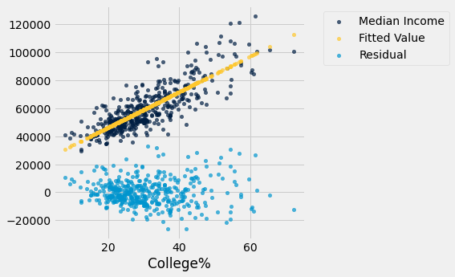

```python
demographics.scatter('College%')
```

```python
def plot_residuals(t, x, y):
    tbl = t.with_columns(
        'Fitted', fitted_values(t, x, y),
        'Residual', residuals(t, x, y)
    )
    tbl.select(x, y, 'Fitted').scatter(0)
    tbl.scatter(x, 'Residual')
```

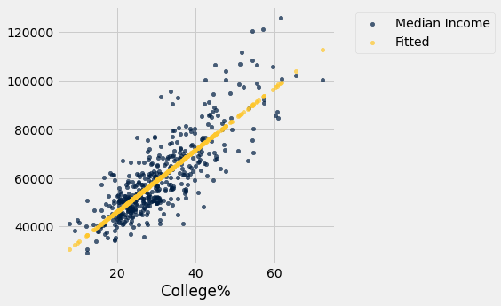

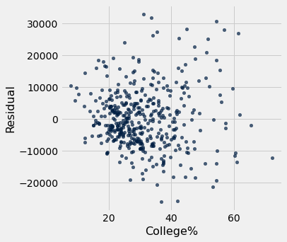

```python
plot_residuals(demographics, 'College%', 'Median Income')
```

Additionally, visualize the residuals associated with the `galton.csv` data set when predicting `Child` values from `Midparent` values using linear regression.

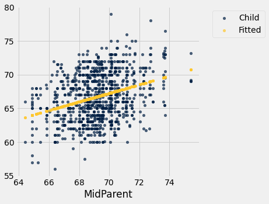

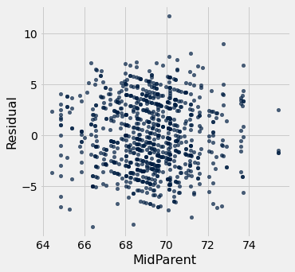

```python
galton = Table.read_table('galton.csv')

heights = Table().with_columns(
    'MidParent', galton.column('midparentHeight'),
    'Child', galton.column('childHeight')
    )
plot_residuals(heights, 'MidParent', 'Child')
```

## Regression Diagnostics

### Example: Dugongs

[figure not shown]

Image Source: [OSU Geospatial Ecology of Marine Megafauna Laboratory](https://blogs.oregonstate.edu/gemmlab/2021/09/27/let-me-introduce-you-to-dugongs/)

### Demo: Dugongs

Visualize the relationship between a dugong's length and age based on the `dugong.csv` dataset. Although the data is not linear, calculate the correlation coefficient.

```python
dugong = Table.read_table('dugong.csv')
dugong.show(5)
```

| Length | Age |
| --- | --- |
| 1.8 | 1 |
| 1.85 | 1.5 |
| 1.87 | 1.5 |
| 1.77 | 1.5 |
| 2.02 | 2.5 |

... (22 rows omitted)

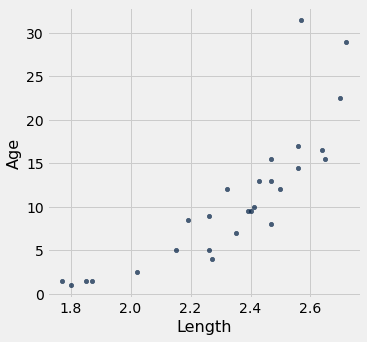

```python
dugong.scatter('Length', 'Age')
```

```python
correlation(dugong, 'Length', 'Age')
```

```
0.8296474554905714
```

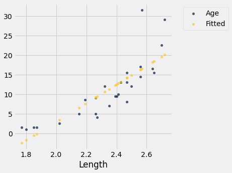

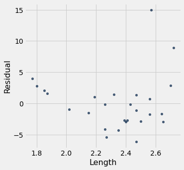

```python
plot_residuals(dugong, 'Length', 'Age')
```

### Residual Plot

A scatter diagram of residuals

- Should look like an unassociated blob for linear relations
- But will show patterns for non-linear relations
- Used to check whether linear regression is appropriate
- Look for curves, trends, changes in spread, outliers, or any other patterns

### Properties of residuals

Residuals from a linear regression always have

- Zero mean (so rmse = SD of residuals)
- Zero correlation with $x$
- Zero correlation with the fitted values

### Reflection

How would we adjust our "regression" line ...

1. if the average residual were 10?
2. if the residuals were positively correlated with x?
3. if the residuals were above 0 in the middle and below 0 on the left and right?

## A Measure of Clustering

### Correlation, Revisited

- "The correlation coefficient measures how clustered the points are about a straight line."
- We can now quantify this statement.

### SD of Fitted Values

- $\frac{\text{SD of fitted values}}{\text{SD of } y} = |r|$
- $\text{SD of fitted values} = |r| \times \text{SD of } y$

### Demo: A Measure of Clustering

Use the datasets to observe the relationship between the standard deviation of the fitted values and the standard deviation of the $y$ values.

```python
def plot_fitted(t, x, y):
    tbl = t.select(x, y)
    tbl.with_columns('Fitted Value', fitted_values(t, x, y)).scatter(0)
```

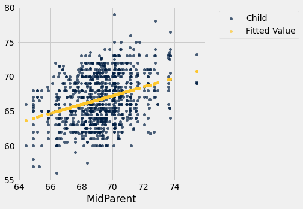

```python
plot_fitted(heights, 'MidParent', 'Child')
```

```python
child_predictions_sd = np.std(fitted_values(heights, 'MidParent', 'Child'))
child_observed_sd = np.std(heights.column('Child'))
print(child_predictions_sd)
print(child_observed_sd)
```

```
1.148145168378806
3.5773346010057634
```

```python
child_predictions_sd / child_observed_sd
```

```
0.32094989606395957
```

```python
correlation(heights, 'MidParent', 'Child')
```

```
0.32094989606395924
```

```python
correlation(dugong, 'Length', 'Age')
```

```
0.8296474554905714
```

```python
dugong_prediction_sd = np.std(fitted_values(dugong, 'Length', 'Age'))
dugong_observed_sd = np.std(dugong.column(1))
dugong_prediction_sd / dugong_observed_sd
```

```
0.8296474554905713
```

```python
hybrid = Table.read_table('hybrid.csv')
hybrid.show(5)
```

| vehicle | year | msrp | acceleration | mpg | class |
| --- | --- | --- | --- | --- | --- |
| Prius (1st Gen) | 1997 | 24509.7 | 7.46 | 41.26 | Compact |
| Tino | 2000 | 35355 | 8.2 | 54.1 | Compact |
| Prius (2nd Gen) | 2000 | 26832.2 | 7.97 | 45.23 | Compact |
| Insight | 2000 | 18936.4 | 9.52 | 53 | Two Seater |
| Civic (1st Gen) | 2001 | 25833.4 | 7.04 | 47.04 | Compact |

... (148 rows omitted)

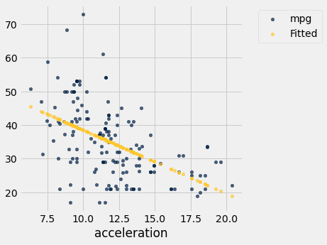

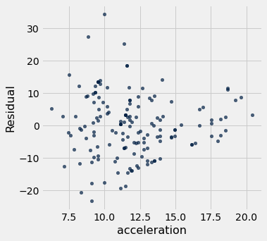

```python
plot_residuals(hybrid, 'acceleration', 'mpg')
```

```python
correlation(hybrid, 'acceleration', 'mpg')
```

```
-0.5060703843771186
```

```python
np.std(fitted_values(hybrid, 'acceleration', 'mpg'))/np.std(hybrid.column('mpg'))
```

```
0.5060703843771186
```

No matter what the shape of the scatter plot, the SD of the fitted values is a fraction of the SD of the observed values of $y$. The fraction is |r|.

$$ \frac{\mbox{SD of fitted values}}{\mbox{SD of }y} ~=~ |r| ~~~~~~~~~~ \mbox{That is,} ~~ \mbox{SD of fitted values} = |r|\cdot \mbox{SD of }y $$

### Variance of Fitted Values

- Variance is the average of the squared deviations.
- Variance has good mathematical properties.
- $$\frac{\text{Variance of fitted values}}{\text{Variance of } y} = r^2$$

### A Variance Decomposition

- By definition $y = \text{fitted values} + \text{residuals}$
- It is tempting to believe that the incorrect statement $\text{SD of } y = \text{SD of fitted values} + \text{SD of residuals}$ ❌
- The correct statement is $$\text{Variance of } y = \text{Variance of fitted values} + \text{Variance of residuals}$$

Related Algebra Class issue: $a^2 + b^2 = c^2$ IS NOT THE SAME AS $\sqrt{a^2} + \sqrt{b^2} = \sqrt{c^2}$ instead it is $\sqrt{a^2 + b^2} = \sqrt{c^2}$

### A Variance Decomposition - Continued

With $\text{Variance of } y = \text{Variance of fitted values} + \text{Variance of residuals}$ and $\frac{\text{Variance of fitted values}}{\text{Variance of } y} = r^2$, then $$\frac{\text{Variance of residuals}}{\text{Variance of } y} = 1 - r^2$$

### Residual Average and SD

- Average of residuals: 0
- $\text{SD of residuals} = \sqrt{1 - r^2} \times \text{SD of y}$

### Demo: Average of Residuals

Notice the following examples support the properties about the residuals expressed above.

```python
round(np.average(residuals(dugong, 'Length', 'Age')), 6)
```

```
0.0
```

```python
round(np.average(residuals(heights, 'MidParent', 'Child')), 6)
```

```
0.0
```

```python
round(np.average(residuals(demographics, 'College%', 'Median Income')), 6)
```

```
0.0
```

```python
heights = heights.with_columns(
    'Residual', residuals(heights, 'MidParent', 'Child'),
    'Fitted Value', fitted_values(heights, 'MidParent', 'Child')
)
```

```python
round(correlation(heights, 'MidParent', 'Residual'), 6)
```

```
-0.0
```

```python
round(correlation(heights, 'Fitted Value', 'Residual'), 6)
```

```
-0.0
```

### Demo: SD of the Residuals

No matter what the shape of the scatter plot, the SD of the residuals is a fraction of the SD of the observed values of $y$. The fraction is $\sqrt{1-r^2}$.

$$ \mbox{SD of residuals} ~=~ \sqrt{1 - r^2} \cdot \mbox{SD of }y $$

Observe this property in the datasets.

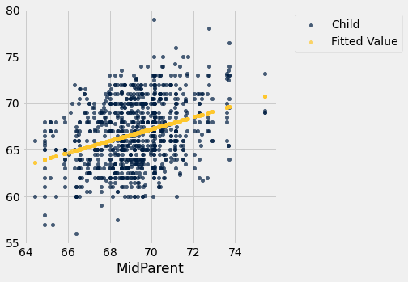

```python
plot_fitted(heights, 'MidParent', 'Child')
```

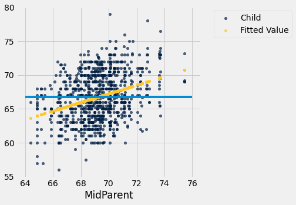

```python
plot_fitted(heights, 'MidParent', 'Child')
ave_child = np.mean(heights.column('Child'))
plots.plot([64, 76], [ave_child, ave_child]);
```

```python
np.std(heights.column('Child')) ** 2
```

```
12.797322847553064
```

```python
np.std(residuals(heights, 'MidParent', 'Child'))
```

```
3.3880799163953426
```

```python
np.std(heights.column('Fitted Value')) ** 2
```

[output not shown]

```python
np.std(dugong.column('Age')) ** 2
```

[output not shown]

```python
np.std(fitted_values(dugong, 'Length', 'Age')) ** 2
```

[output not shown]

```python
np.std(residuals(dugong, 'Length', 'Age')) ** 2
```

[output not shown]

```python
r = correlation(heights, 'MidParent', 'Child')
r
```

```
0.32094989606395924
```

```python
np.sqrt(1 - r**2) * np.std(heights.column('Child'))
```

```
3.388079916395342
```

```python
np.std(residuals(hybrid, 'acceleration', 'mpg'))
```

```
9.43273683343029
```

```python
r = correlation(hybrid, 'acceleration', 'mpg')
r
```

```
-0.5060703843771186
```

```python
np.sqrt(1 - r**2)*np.std(hybrid.column('mpg'))
```

```
9.43273683343029
```

### Example 1

- Midterm: Average 70, SD 10
- Final: Average 60, SD 15
- r = 0.6
- The SD of the residuals is ___.

```python
r = 0.6
SD_Y = 15
SD_residuals = np.sqrt(1 - r ** 2) * SD_Y
SD_residuals
```

```
12.0
```

### Example 2

- Midterm: Average 70, SD 10
- Final: Average 60, SD 15
- r = 0.6
- For at least 75% of the students, the regression estimate of final score based on midterm score will be correct to within ___ points.

```python
# Chebychev!

2*SD_residuals
```

```
24.0
```